# Reproducible Research: Peer Assessment 1

```r
library(dplyr)
library(chron)
```

## Loading and preprocessing the data

Here you can find the data loading (read.csv) and some date and time transformation in order to make formatted date and proper date-time variable for potential date operations.

```r
setwd("c:/R/Coursera - R Programming/RepData_PeerAssessment1")
unzip("activity.zip")
df<-read.csv("activity.csv", sep=",", na.strings = "NA")

min<-ifelse (nchar(as.character(df$interval))<=2, df$interval,
          as.numeric(substr(df$interval, nchar(df$interval) - 1,
          nchar(df$interval))))
hour<-ifelse (nchar(as.character(df$interval))<=2, 0,
          ifelse (nchar(as.character(df$interval))==3,
            substr(df$interval, 1, 1), substr(df$interval, 1, 2)))
time<-paste(hour,":",min,":00",sep="")
df$DateTime<-as.POSIXct(paste(df$date, time), format="%Y-%m-%d %H:%M:%S")
df$date<-as.Date(df$date)
```

## What is mean total number of steps taken per day?

First aggregate the sum of steps for each day then draw a histogram for it.

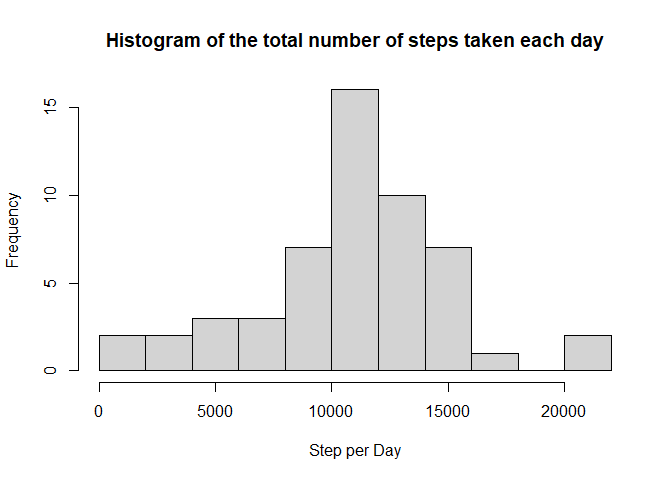

```r
StepPerDay <- df %>%
  group_by(date) %>%
  summarize(steps=sum(steps),.groups = 'drop')

hist(StepPerDay$steps,breaks=10,
  main="Histogram of the total number of steps taken each day",
  xlab="Step per Day")
```

#### Mean and median number of steps taken each day

```r
mean(StepPerDay$steps,na.rm=TRUE)
```

```
## [1] 10766.19
```

```r
median(StepPerDay$steps,na.rm=TRUE)
```

```
## [1] 10765
```

## What is the average daily activity pattern?

In the following code chunk I’ve used the “onlytime” variable which made with chron and hase Times object class. Unfortunately base plotting system can’t use this variable for proper x axis labels, as a result I’ve inserted a manual labeling for the horizontal axis.

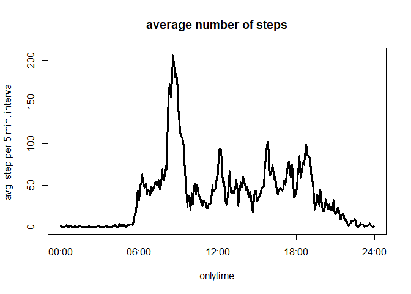

```r
df$onlytime <- times(strftime(df$DateTime,"%H:%M:%S"))
StepPerInt <- df %>%
  group_by(onlytime) %>%
  summarize(steps=mean(steps,na.rm=TRUE),.groups = 'drop')
with(StepPerInt,plot(onlytime,steps,type="l",lwd=3,
  main="average number of steps",
  ylab="avg. step per 5 min. interval",xaxt='n'))
axis(1,at=c(0,.25,.5,.75,1),labels=c("00:00","06:00","12:00","18:00","24:00"))
```

Which 5-minute interval, on average across all the days in the dataset, contains the maximum number of steps? Here is the answer:

```r
StepPerInt$onlytime[which.max(StepPerInt$steps)]
```

```
## [1] 08:35:00
```

## Imputing missing values

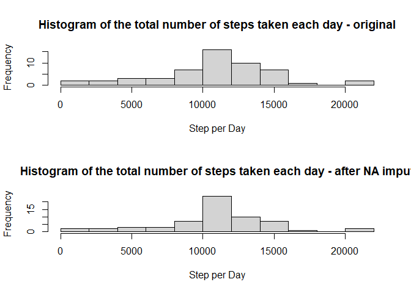

```r
df$weekdays<-weekdays(df$date)
df <- df %>%
  group_by(weekdays) %>%
  group_by(interval) %>%
  mutate(temp = mean(steps,na.rm=TRUE))
df$stepswoNA <- ifelse(is.na(df$steps), df$temp , df$steps)
df <- subset(df, select = -c(6) )

df2<-df
df2 <- subset(df2, select = -c(1) )
names(df2)[names(df2) == "stepswoNA"] <- "steps"

StepPerDay2 <- df2 %>%
  group_by(date) %>%
  summarize(steps=sum(steps),.groups = 'drop')

par(mfrow=c(2,1))
hist(StepPerDay$steps,breaks=10,
  main="Histogram of the total number of steps taken each day - original",
  xlab="Step per Day")
hist(StepPerDay2$steps,breaks=10,
  main="Histogram of the total number of steps taken each day - after NA imput",
  xlab="Step per Day")
```

```r
# original
mean(StepPerDay$steps,na.rm=TRUE)
```

```
## [1] 10766.19
```

```r
median(StepPerDay$steps,na.rm=TRUE)
```

```
## [1] 10765
```

```r
# imputed
mean(StepPerDay2$steps,na.rm=TRUE)
```

```
## [1] 10766.19
```

```r
median(StepPerDay2$steps,na.rm=TRUE)
```

```
## [1] 10766.19
```

## Are there differences in activity patterns between weekdays and weekends?

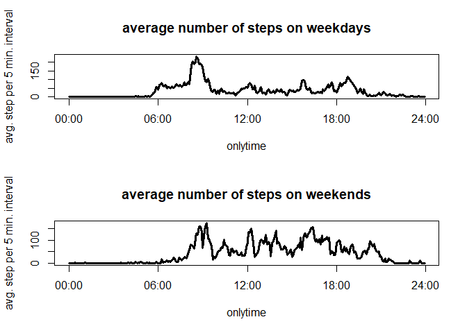

```r
df$weekdays<-ifelse(weekdays(df$date)%in%c("szombat","vasárnap"),
  "weekend","weekday")
StepPerIntWD <- df %>%
  filter(weekdays=="weekday") %>%
  group_by(onlytime) %>%
  summarize(steps=mean(steps,na.rm=TRUE),.groups = 'drop')
StepPerIntWE <- df %>%
  filter(weekdays=="weekend") %>%
  group_by(onlytime) %>%
  summarize(steps=mean(steps,na.rm=TRUE),.groups = 'drop')
par(mfrow=c(2,1))
with(StepPerIntWD,plot(onlytime,steps,type="l",lwd=3,
  main="average number of steps on weekdays",
  ylab="avg. step per 5 min. interval",xaxt='n'))
axis(1,at=c(0,.25,.5,.75,1),labels=c("00:00","06:00","12:00","18:00","24:00"))
with(StepPerIntWE,plot(onlytime,steps,type="l",lwd=3,
  main="average number of steps on weekends",
  ylab="avg. step per 5 min. interval",xaxt='n'))
axis(1,at=c(0,.25,.5,.75,1),labels=c("00:00","06:00","12:00","18:00","24:00"))
```